# Examen final de Introducción a R - Versión A

Bioinformática I — Versión A

Autor/a

Adara Salas-Manzo

## Instrucciones generales

**Duración: 120 minutos. Valor total: 100 puntos.**

El objetivo es reproducir dos figuras a partir de datos reales de mieles de abejas sin aguijón. Los conteos proporcionados corresponden únicamente a bacterias con asignación taxonómica a nivel de género. Se incluyen 17 muestras de dos especies de abejas.

Trabaja en tu proyecto de RStudio y utiliza este documento como [plantilla](https://github.com/CursosENESJuriquilla/Intro_to_R_Bioinfo_2027-1/raw/refs/heads/main/versionA.qmd). Sustituye el nombre del autor por el tuyo. Agrega tus bloques de código R ejecutables y tus respuestas en las secciones correspondientes. Conserva las rutas relativas y muestra el procedimiento completo. Las figuras de referencia son una guía: no es necesario reproducir exactamente la tipografía ni los tamaños.

## Importación y exploración (10 puntos)

Descarga y descomprime datos_A.zip. Importa con `readr` los archivos `conteos_genero_miel_bacterias.tsv` y `datos/metadata_miel_examen.csv`.

**Código**

```r
library(readr)
library(dplyr)
library(tidyr)
library(ggplot2)


conteos_miel = readr::read_tsv("../data_raw/datos_A/conteos_genero_miel_bacterias.tsv")
metadata_miel = readr::read_csv("../data_raw/datos_A/metadata_miel_examen.csv")
```

- Indica las dimensiones de ambas tablas y el número de muestras por especie de abeja.

  **Código**

  ```r
  dimensiones_conteos = dim(conteos_miel)
  cat("La tabla del archivo 'conteos_genero_miel_bacterias' tiene dimensiones de 37128 filas y 3 columnas", "\n")
  ```

  ```
  La tabla del archivo 'conteos_genero_miel_bacterias' tiene dimensiones de 37128 filas y 3 columnas
  ```

  **Código**

  ```r
  dimensiones_metadata = dim(metadata_miel)
  cat("La tabla del archivo 'metadata_miel_examen' tiene dimensiones de 17 filas y 14 columnas", "\n")
  ```

  ```
  La tabla del archivo 'metadata_miel_examen' tiene dimensiones de 17 filas y 14 columnas
  ```

  **Código**

  ```r
  muestras_especie = metadata_miel %>%
    distinct(sample_id, species) %>%
    count(species, name = "num_muestras")
  muestras_especie
  ```

  ```
  # A tibble: 2 × 2
    species                num_muestras
    <chr>                         <int>
  1 Melipona beecheii                 9
  2 Scaptotrigona mexicana            8
  ```

- Identifica si existen valores faltantes en los metadatos e indica en qué variable o variables.

  **Código**

  ```r
  colSums(is.na(conteos_miel))
  ```

  ```
  sample_id    genero    conteo
          0         0         0
  ```

  **Código**

  ```r
  cat("En el archivo 'conteos_genero_miel_bacterias', no existen valores faltantes.", "\n")
  ```

  ```
  En el archivo 'conteos_genero_miel_bacterias', no existen valores faltantes.
  ```

  **Código**

  ```r
  colSums(is.na(metadata_miel))
  ```

  ```
             sample_id              species                State
                     0                    0                    0
                  City               Region Zootechnic_mangement
                     0                    0                    0
        Flowering_type             Moisture                  HMF
                     0                    0                    0
                 Color                   pH         Conductivity
                     0                    0                    0
                   Ash          Total_sugar
                     0                    2
  ```

  **Código**

  ```r
  cat("En el archivo 'metadata_miel_examen' hay dos valores faltantes en la variable Total_sugar")
  ```

  ```
  En el archivo 'metadata_miel_examen' hay dos valores faltantes en la variable Total_sugar
  ```

## Integración y abundancia relativa (20 puntos)

Integra las dos tablas mediante el identificador `sample_id`. Calcula la abundancia relativa de cada género dentro de cada muestra, dividiendo su conteo entre la suma de los conteos de esa muestra. Conserva las abundancias como proporciones entre 0 y 1.

**Código**

```r
datos = conteos_miel %>%
  left_join(
    metadata_miel %>% select(sample_id, species),
    by = "sample_id",
  )

abundancias_genero_conteos = datos %>%
  mutate(genero = if_else(is.na(genero), "Sin clasificar", genero)) %>%
  group_by(sample_id, genero, species) %>%
  summarise(conteo = sum(conteo), .groups = "drop") %>%
  group_by(sample_id) %>%
  mutate(abundancia_relativa = conteo / sum(conteo)) %>%
  ungroup()

abundancias_genero_conteos %>%
  select(sample_id, genero, conteo, species, abundancia_relativa) %>%
  head()
```

```
# A tibble: 6 × 5
  sample_id genero        conteo species           abundancia_relativa
  <chr>     <chr>          <dbl> <chr>                           <dbl>
1 Melli_21  Abiotrophia      806 Melipona beecheii         0.000132
2 Melli_21  Abyssalbus        66 Melipona beecheii         0.0000108
3 Melli_21  Abyssibius         3 Melipona beecheii         0.000000491
4 Melli_21  Abyssicoccus     853 Melipona beecheii         0.000140
5 Melli_21  Acaryochloris    867 Melipona beecheii         0.000142
6 Melli_21  Aceticella        11 Melipona beecheii         0.00000180
```

## Figura 1: los 10 géneros más abundantes (25 puntos)

Calcula la abundancia relativa promedio de cada género considerando las 17 muestras, incluidos los conteos cero. Selecciona los diez con mayor promedio y reproduce la gráfica de barras horizontales ordenadas de mayor a menor. Muestra el eje de abundancia en porcentajes y agrega etiquetas apropiadas.

[figure not shown]

Figura 1. Referencia.

**Código**

```r
top_10_generos = abundancias_genero_conteos %>%
  group_by(genero) %>%
  summarise(abundancia_promedio = mean(abundancia_relativa), .groups = "drop") %>%
  arrange(desc(abundancia_promedio)) %>%
  slice_head(n = 10)

top_10_generos
```

```
# A tibble: 10 × 2
   genero              abundancia_promedio
   <chr>                             <dbl>
 1 Acetilactobacillus               0.314
 2 Apilactobacillus                 0.0653
 3 Nicoliella                       0.0617
 4 Lactobacillus                    0.0356
 5 Lentilactobacillus               0.0266
 6 Fructilactobacillus              0.0258
 7 Ligilactobacillus                0.0206
 8 Pediococcus                      0.0198
 9 Tatumella                        0.0195
10 Limosilactobacillus              0.0187
```

**Código**

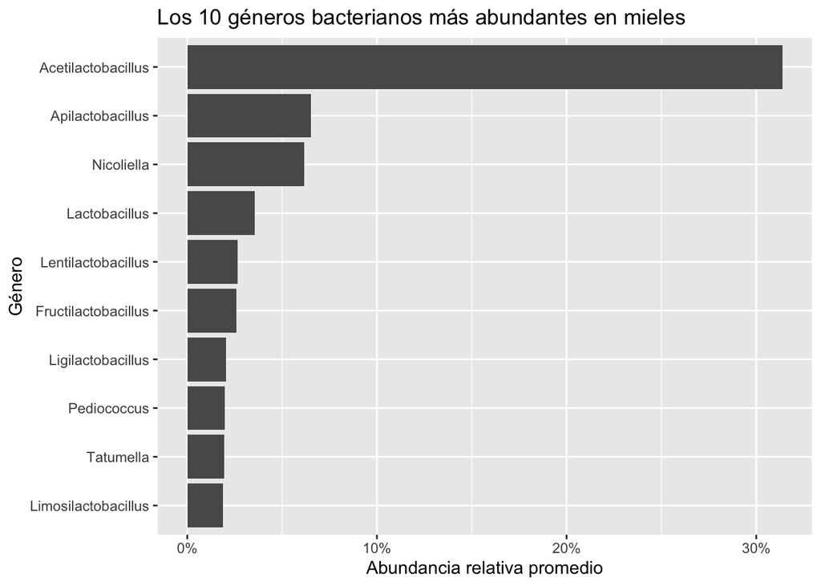

```r
tabla_top_10 = ggplot(top_10_generos,
                      aes(x = abundancia_promedio,,
                          y = reorder(genero, abundancia_promedio))) +
  geom_col() +
  labs(title = "Los 10 géneros bacterianos más abundantes en mieles",
       x = "Abundancia relativa promedio",
       y = "Género") +
  scale_x_continuous(labels = scales::percent)
tabla_top_10
```

## Figura 2: composición bacteriana por muestra (30 puntos)

Utiliza las abundancias relativas del apartado 2, **no solamente los diez taxones de la figura anterior**.

- Dentro de cada muestra, agrupa los géneros cuya abundancia relativa sea estrictamente menor al 5 % en la categoría `Géneros < 5%`. Suma las abundancias de esa categoría.

**Código**

```r
generos_5 = abundancias_genero_conteos %>%
  mutate(
    taxon_final = if_else(
      abundancia_relativa < 0.05, "Géneros < 5%", genero
    )) %>%
  group_by(sample_id, species, taxon_final) %>%
  summarise(
    abundancia_relativa = sum(abundancia_relativa),
    .groups = "drop"
  )


comprobacion = generos_5 %>%
  group_by(sample_id) %>%
  summarise(total = sum(abundancia_relativa), .groups = "drop")

stopifnot(all(abs(comprobacion$total - 1) < 1e-8))


head(generos_5, n = 10)
```

```
# A tibble: 10 × 4
   sample_id species           taxon_final        abundancia_relativa
   <chr>     <chr>             <chr>                            <dbl>
 1 Melli_21  Melipona beecheii Acetilactobacillus              0.660
 2 Melli_21  Melipona beecheii Géneros < 5%                    0.340
 3 Melli_22  Melipona beecheii Acetilactobacillus              0.680
 4 Melli_22  Melipona beecheii Géneros < 5%                    0.320
 5 Melli_39  Melipona beecheii Acetilactobacillus              0.674
 6 Melli_39  Melipona beecheii Géneros < 5%                    0.326
 7 Melli_40  Melipona beecheii Acetilactobacillus              0.531
 8 Melli_40  Melipona beecheii Géneros < 5%                    0.385
 9 Melli_40  Melipona beecheii Nicoliella                      0.0838
10 Melli_41  Melipona beecheii Acetilactobacillus              0.407
```

- Construye una gráfica de barras apiladas, una barra por muestra, separando las especies de abejas mediante facetas. Cada barra debe sumar 100 %.

**Código**

```r
genus_colors <- c(
  "Acetilactobacillus" = "#002868",
  "Apilactobacillus" = "#0077C2",
  "Lactobacillus" = "#66B2FF",
  "Nicoliella" = "#ADD8E1",
  "Pantoea" = "#008080",
  "Tatumella" = "#98FB98",
  "Fructobacillus" = "#007BA7",
  "Géneros < 5%" = "#778899"
)
```

**Código**

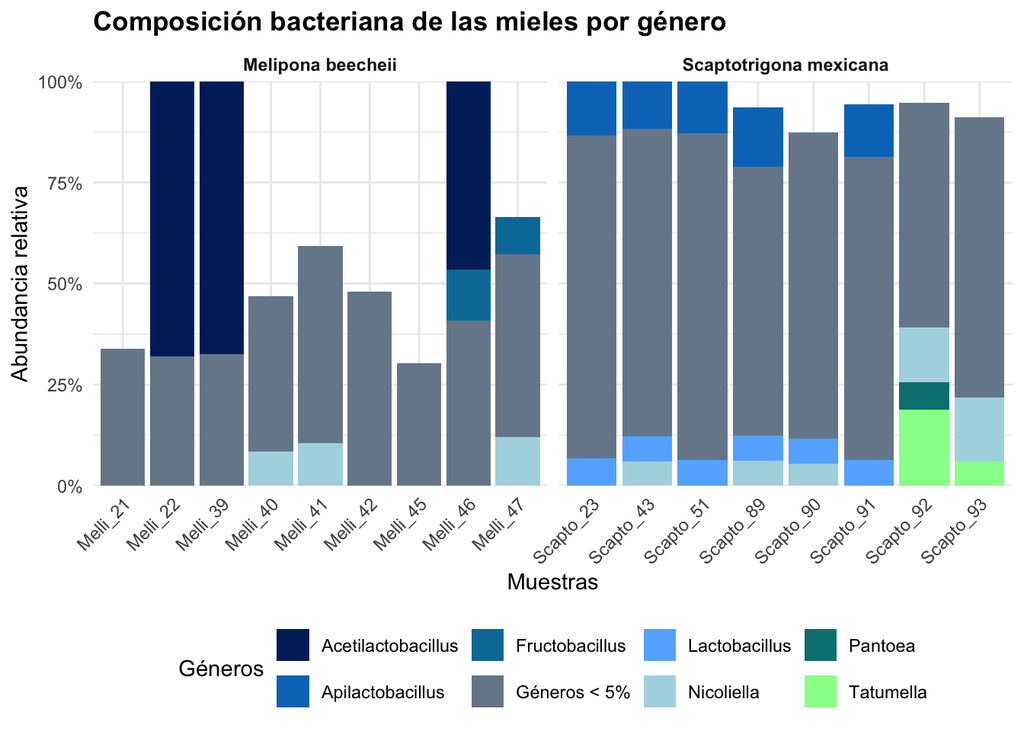

```r
tabla_generos_5 = ggplot(generos_5,
                         aes(x = sample_id,
                             y = abundancia_relativa,
                             fill = taxon_final)) +
  geom_col(position = "stack") +
  facet_wrap(~ species, scales = "free_x") +
  scale_fill_manual(values = genus_colors) +
  scale_y_continuous(
    labels = function(x) paste0(round(100 * x), "%"),
    limits = c(0,1),
    expand = c(0,0)
  ) +
  labs(
    title = "Composición bacteriana de las mieles por género",
    x = "Muestras",
    y = "Abundancia relativa",
    fill = "Géneros"
  ) +
  theme_minimal() +
  theme(
    plot.title = element_text(face = "bold"),
    strip.text = element_text(face = "bold"),
    axis.text.x = element_text(angle = 45, hjust = 1),
    legend.position = "bottom"
  )

tabla_generos_5
```

- Utiliza la paleta proporcionada y coloca la leyenda debajo de la gráfica.

Paleta de referencia (puedes copiarla en un bloque de R) o puedes usar otra paleta de colores:

```r
genus_colors <- c(
  "Acetilactobacillus" = "#002868",
  "Apilactobacillus" = "#0077C2",
  "Lactobacillus" = "#66B2FF",
  "Nicoliella" = "#ADD8E1",
  "Pantoea" = "#008080",
  "Tatumella" = "#98FB98",
  "Fructobacillus" = "#007BA7",
  "Géneros < 5%" = "#778899"
)
```

[figure not shown]

Figura 2. Referencia.

## Interpretación (5 puntos)

Responde brevemente con base en tus resultados:

1. ¿Cuál es el género con mayor abundancia relativa promedio?

   El género con mayor abundancia relativa promedio es Acetilactobacillus, con una abundancia promedio de 0.314
2. ¿Qué diferencias o similitudes observas en la composición de las muestras de las dos especies de abejas?

**Nota**: Todas las muestras pertenecen al mismo estudio y fueron procesadas con la misma metodología.

## Reporte reproducible y entrega (10 puntos)

Renderiza el documento a HTML y sube a tu repositorio de GitHub el archivo `.qmd`, el HTML generado y las carpetas de datos y figuras necesarias. Verifica que el HTML muestre tus resultados y gráficas sin necesidad de ejecutar el código nuevamente. Entrega el enlace al repositorio.

Si tienes un problema técnico con GitHub, conserva el `.qmd` y el HTML y notifícalo a la profesora antes de finalizar el examen.